# Week 9

Queueing Simulation

Gareth Green

# Queueing simulation

# Code the standard `queueing` set up

- First will find L, Lq, W and Wq using `queueing` package so we have a base line of comparison
  - when possible you want to have a comparison for results of your own model to verify accuracy of your results

```r
# Set up problem with initial criteria and 10 customers
lam <- 3; mu <- 5 ; s <- 1;

# Using "queueing" package
q <- NewInput.MMC(lambda = lam, mu = mu, c = s)
q_mod <- QueueingModel.i_MMC(q)
# Place results as a row in a table
  # Multiply wait by 60 minutes in an hour to convert time from hours to minutes
q_tab <- data.frame(t(round(c(s, q_mod$L, q_mod$Lq, q_mod$W*60, q_mod$Wq*60), 2)))

colnames(q_tab) <- c("Servers", "L", "Lq", "W (minutes)", "Wq (minutes)")
```

Queueing package mean steady state results

| Servers | L | Lq | W (minutes) | Wq (minutes) |
| --- | --- | --- | --- | --- |
| 1 | 1.5 | 0.9 | 30 | 18 |

# Poisson and exponential distributions

- An interesting feature of the two distributions:
  - The Poisson shows the number of occurrences per time interval
  - The exponential shows the length of time between occurrences
- To set up the simulation model I will model the length between intervals of arrivals and service time
  - I initially tried modeling the number of occurrences per time interval using the Poisson
  - it did not work because I could not model the time in the queue
- It is not unusual when you build a model that you have to modify your approach to find the variables of interest

```r
# Number of random variables
n <- 1000

# Number of customers in each run, which is about 1 week worth of business if lam = 3 per hour
cust <- 250

# Number of runs, i.e. number of weeks
runs <- n

# Set seed to get consistent results while coding
set.seed(3)

# Generate random variables
e_arr <- rexp(n, rate = lam)
e_ser <- rexp(n, rate = mu)
```

# Coding the customer loop

- The model will take two stages
  1. the model of customer arrival and service for a given number of customers
     - in this case 250, about a weeks worth of customers
  2. the loop to run the model many times
     - 1000 times in this case, about 19 years worth of weeks
- When I first coded the model I used data.frame
  - once running I converted to matrix, waaaaaayyyyyyy faster
    - should have done that from the beginning
  - I could convert each loop to be a function but am short on time
- So what is going on in this model!?

```r
# Build a table of results
tab <- matrix(0, cust, 7)

# Set initial time, wait time
arr_time <- 0; beg_time <- 0; end_time <- 0; wait_time <- 0

# Set up loop for every customer
for(i in 1:cust){
  # Minutes till next customer arrives to the system
  t_arr <- round(sample(e_arr, 1, replace = TRUE) * 60, 0)

  # Time at customer arrival
  arr_time <- arr_time + t_arr

  # Customer wait time
  wait_time <- ifelse(end_time > arr_time, end_time - arr_time, 0)

  # Set service begin time
  beg_time <- arr_time + wait_time

  # Random service times for each customer
  t_ser <- round(sample(e_ser, 1, replace = TRUE) * 60, 0)

  # Set time service ends
  end_time <- beg_time + t_ser

  # Combine in a table
  tab[i, ] <- round(c(i, t_arr, arr_time, beg_time, t_ser, end_time, wait_time), 1)
}
```

# Coding the weeks loop

- Need to run the 250 customers through 1000 weeks
  - this code does not have the customer loop in it yet

```r
# Initialize results table
total <- matrix(0, runs, 5)

# Set loop for each week of runs
for(j in 1:runs){
  # Build a table of results
  tab <- matrix(0, cust, 8)

  # Set initial time, wait time
  arr_time <- 0; beg_time <- 0; end_time <- 0; wait_time <- 0

  # Set up loop for every customer

# ---- PLACE CUSTOMER LOOP HERE ---- #

  # System results, column 7 is Wait, column 5 is service time, column 2 is arrival time
  total[j, ] <- matrix(t(c(cust,
                          (sum(tab[,7])/cust + sum(tab[,5])/cust)*(60/mean(tab[,2]))/60,
                          (sum(tab[,7])/cust)*(60/mean(tab[,2]))/60,
                          sum(tab[,7])/cust + sum(tab[,5])/cust,
                          sum(tab[,7])/cust)))
}

# Put header on table and name the header in the same line of code
colnames(total) <- t_name <- c("Customers", "L", "Lq", "W", "Wq")
```

# Run the combined loops

```r
# Initialize results table
total <- matrix(0, runs, 5)

# Set loop for each week of runs
for(j in 1:runs){
  # Build a table of results
  tab <- matrix(0, cust, 7)

  # Set initial time, wait time
  arr_time <- 0; beg_time <- 0; end_time <- 0; wait_time <- 0

  # Set up loop for every customer
  for(i in 1:cust){
    # Minutes till next customer arrives to the system
    t_arr <- round(sample(e_arr, 1, replace = TRUE) * 60, 0)

    # Time at customer arrival
    arr_time <- arr_time + t_arr

    # Customer wait time
    wait_time <- ifelse(end_time > arr_time, end_time - arr_time, 0)

    # Set service begin time
    beg_time <- arr_time + wait_time

    # Random service times for each customer
    t_ser <- round(sample(e_ser, 1, replace = TRUE) * 60, 0)

    # Set time service ends
    end_time <- beg_time + t_ser

    # Combine in a table
    tab[i, ] <- round(c(i, t_arr, arr_time, beg_time, t_ser, end_time, wait_time), 1)
  }

  # System results, column 7 is Wait, column 5 is service time, column 2 is arrival time
  total[j, ] <- matrix(t(c(cust,
                          (sum(tab[,7])/cust + sum(tab[,5])/cust)*(60/mean(tab[,2]))/60,
                          (sum(tab[,7])/cust)*(60/mean(tab[,2]))/60,
                          sum(tab[,7])/cust + sum(tab[,5])/cust,
                          sum(tab[,7])/cust)))
}

# Put header on table and name the header in the same line of code
colnames(total) <- t_name <- c("Customers", "L", "Lq", "W", "Wq")
```

# Table of key results

Queueing package mean steady state results

| Servers | L | Lq | W (minutes) | Wq (minutes) |
| --- | --- | --- | --- | --- |
| 1 | 1.5 | 0.9 | 30 | 18 |

Custom queueing model simulation results

|  | L | Lq | W | Wq |
| --- | --- | --- | --- | --- |
| mean | 1.48 | 0.87 | 28.97 | 17.08 |
| sd | 0.40 | 0.36 | 6.81 | 6.39 |
| max | 4.84 | 4.07 | 77.82 | 65.51 |
| min | 0.71 | 0.27 | 14.92 | 5.61 |

# Distribution of key variables

- **red line** is mean from simulation, **blue line** is mean from `queueing` package

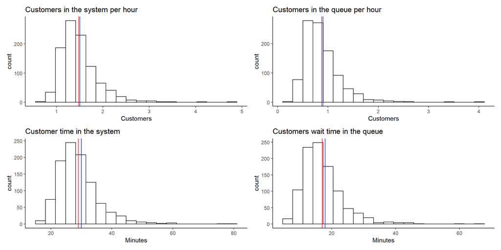

# Monte Carlo simulation

- The goal of simulation is to understand he performance of a system
  - You are simulating a system because you cannot run experiments
- Monte Carlo simulation incorporates uncertainty
  - Illuminates the impact of uncertainty on your system
- There are numerous ways to run Monte Carlo simulation
  - But the general approach is the same
- We only several types of random variables
  - Could have pulled observations from actual data
  - treat like empirical distribution